Empolyee Attrition and Retention Strategies

[figure not shown]

# Empolyee Attrition and Retention Strategies

Arja Rasagna

April 26, 2024

# Employee Attrition and retention strategies

Master’s Research Project – 3  
Rasagna Arja  
Saint Louis University  
AA-5963-22

## Introduction:

This study aims to build a reliable and accurate model for predicting employee attrition using the IBM HR Analytics Attrition dataset. The algorithm estimates the likelihood of an employee leaving the company based on various factors such as work-life balance, performance ratings, and demographic data. These predictive insights can be very beneficial for organizations, as they can enable them to take preventive measures to retain key employees and reduce the costs associated with high turnover rates.

#### Setup (ignore)

```python
# Monting and connection to Google drive
from google.colab import drive
drive.mount('/content/drive')
```

```python
#Setting path to dataset folder
import os
os.chdir('/content/drive/MyDrive/MRP/Dataset/')
```

```python
#Importing requried lib

# Week 1
import pandas as pd
import numpy as np
from sklearn.preprocessing import LabelEncoder, OneHotEncoder
```

```python
# Week 2 imports
import matplotlib.pyplot as plt
import seaborn as sns
```

## Dataset Overview:

The IBM HR Analytics Attrition dataset contains 1470 rows and 35 columns. The target variable is "Attrition", which indicates whether the employee left the organization or not. The dataset also has various features, such as: Demographic information such as age, gender, marital status, and education field. Job-related factors such as job role, job level, job satisfaction, performance rating, years at the company. Work-life balance indicators such as overtime, monthly income, travel time, work-life balance score. Employee satisfaction measures such as satisfaction environment, job involvement, relationship satisfaction. Training and education details such as training times last year, education level, education field.

Dataset : https://www.kaggle.com/datasets/pavansubhasht/ibm-hr-analytics-attrition-dataset

```python
# Load the dataset
df = pd.read_csv('AttritionDataset.csv')
```

```python
# Befor cleaning
df.info()
```

```
<class 'pandas.core.frame.DataFrame'>
RangeIndex: 1470 entries, 0 to 1469
Data columns (total 35 columns):
 #   Column                    Non-Null Count  Dtype
---  ------                    --------------  -----
 0   Age                       1470 non-null   int64
 1   Attrition                 1470 non-null   object
 2   BusinessTravel            1470 non-null   object
 3   DailyRate                 1470 non-null   int64
 4   Department                1470 non-null   object
 5   DistanceFromHome          1470 non-null   int64
 6   Education                 1470 non-null   int64
 7   EducationField            1470 non-null   object
 8   EmployeeCount             1470 non-null   int64
 9   EmployeeNumber            1470 non-null   int64
```

[output cut: 27 more lines]

## Week 1 | Data Cleaning and Preprocessing

In the first week of the research project, the focus was on preparing the dataset for modeling by performing various data cleaning and preprocessing steps. The IBM HR Analytics Attrition dataset was used, which contained information about employees, including their demographic data, job details, and whether they left the company (attrition) or not.

### Handling Missing Values:

The dataset was checked for missing values, and the number of missing values in each column was reported.

```python
# Check for missing values
print(df.isnull().sum())
```

```
Age                         0
Attrition                   0
BusinessTravel              0
DailyRate                   0
Department                  0
DistanceFromHome            0
Education                   0
EducationField              0
EmployeeCount               0
EmployeeNumber              0
EnvironmentSatisfaction     0
Gender                      0
HourlyRate                  0
JobInvolvement              0
JobLevel                    0
JobRole                     0
JobSatisfaction             0
MaritalStatus               0
MonthlyIncome               0
MonthlyRate                 0
NumCompaniesWorked          0
Over18                      0
OverTime                    0
PercentSalaryHike           0
PerformanceRating           0
RelationshipSatisfaction    0
StandardHours               0
StockOptionLevel            0
TotalWorkingYears           0
TrainingTimesLastYear       0
WorkLifeBalance             0
YearsAtCompany              0
YearsInCurrentRole          0
YearsSinceLastPromotion     0
YearsWithCurrManager        0
dtype: int64
```

### Removing Duplicates

Duplicate rows, if present, were identified and removed from the dataset to prevent biased modeling results.

```python
# Remove duplicates
data = df.drop_duplicates()
```

```python
# After cleaning
data.info()
```

```
<class 'pandas.core.frame.DataFrame'>
RangeIndex: 1470 entries, 0 to 1469
Data columns (total 35 columns):
 #   Column                    Non-Null Count  Dtype
---  ------                    --------------  -----
 0   Age                       1470 non-null   int64
 1   Attrition                 1470 non-null   object
 2   BusinessTravel            1470 non-null   object
 3   DailyRate                 1470 non-null   int64
 4   Department                1470 non-null   object
 5   DistanceFromHome          1470 non-null   int64
 6   Education                 1470 non-null   int64
 7   EducationField            1470 non-null   object
 8   EmployeeCount             1470 non-null   int64
 9   EmployeeNumber            1470 non-null   int64
```

[output cut: 27 more lines]

### Encoding Categorical Variables:

The dataset contained several categorical variables, such as

- 'Attrition'
- 'BusinessTravel'
- 'Department'
- 'EducationField'
- 'Gender'
- 'JobRole'
- 'MaritalStatus'
- 'Over18'
- 'OverTime'

Lable encoding was used to convert variables into a numerical format suitable for machine learning algorithms. The scikit-learn library's LableEncoder was used for this purpose.

```python
from sklearn.preprocessing import LabelEncoder

# Create a LabelEncoder object
le = LabelEncoder()

# Apply LabelEncoder to each column of the DataFrame
for col in data.columns:
    # Check if the column is of object type
    if data[col].dtype == 'object':
        # If yes, convert it into categorical codes
        data[col] = le.fit_transform(data[col])
```

```python
# After Encoding
data.info()
```

```
<class 'pandas.core.frame.DataFrame'>
RangeIndex: 1470 entries, 0 to 1469
Data columns (total 35 columns):
 #   Column                    Non-Null Count  Dtype
---  ------                    --------------  -----
 0   Age                       1470 non-null   int64
 1   Attrition                 1470 non-null   int64
 2   BusinessTravel            1470 non-null   int64
 3   DailyRate                 1470 non-null   int64
 4   Department                1470 non-null   int64
 5   DistanceFromHome          1470 non-null   int64
 6   Education                 1470 non-null   int64
 7   EducationField            1470 non-null   int64
 8   EmployeeCount             1470 non-null   int64
 9   EmployeeNumber            1470 non-null   int64
```

[output cut: 27 more lines]

### Scaling Numerical Variables:

The numerical variables in the dataset, such as

- 'Age'
- 'DailyRate'
- 'DistanceFromHome'
- 'Education'
- 'EmployeeCount'

These variables were scaled using the MinMaxScaler from scikit-learn. This scaling technique ensures that all numerical features are on a similar scale, which can improve the performance of certain machine learning algorithms and prevent features with larger values from dominating the modeling process.

```python
from sklearn.preprocessing import MinMaxScaler

scaler = MinMaxScaler()

# Scale the numerical columns
data = pd.DataFrame(scaler.fit_transform(data), columns=data.columns)
```

```python
# after scaling
data.info()
```

```
<class 'pandas.core.frame.DataFrame'>
RangeIndex: 1470 entries, 0 to 1469
Data columns (total 35 columns):
 #   Column                    Non-Null Count  Dtype
---  ------                    --------------  -----
 0   Age                       1470 non-null   float64
 1   Attrition                 1470 non-null   float64
 2   BusinessTravel            1470 non-null   float64
 3   DailyRate                 1470 non-null   float64
 4   Department                1470 non-null   float64
 5   DistanceFromHome          1470 non-null   float64
 6   Education                 1470 non-null   float64
 7   EducationField            1470 non-null   float64
 8   EmployeeCount             1470 non-null   float64
 9   EmployeeNumber            1470 non-null   float64
```

[output cut: 27 more lines]

## Week 2 | Exploratory Data Analysis

In Week 2, an in-depth exploratory data analysis (EDA) was conducted on the IBM HR Analytics Attrition dataset to gain insights into the data and understand the relationships between variables.

```python
print(data.describe())
```

```
               Age    Attrition  BusinessTravel    DailyRate   Department  \
count  1470.000000  1470.000000     1470.000000  1470.000000  1470.000000
mean      0.450567     0.161224        0.803741     0.501421     0.630272
std       0.217509     0.367863        0.332727     0.288840     0.263896
min       0.000000     0.000000        0.000000     0.000000     0.000000
25%       0.285714     0.000000        0.500000     0.259843     0.500000
50%       0.428571     0.000000        1.000000     0.501074     0.500000
75%       0.595238     0.000000        1.000000     0.755190     1.000000
max       1.000000     1.000000        1.000000     1.000000     1.000000

       DistanceFromHome    Education  EducationField  EmployeeCount  \
count       1470.000000  1470.000000     1470.000000         1470.0
mean           0.292590     0.478231        0.449524            0.0
std            0.289531     0.256041        0.266274            0.0
min            0.000000     0.000000        0.000000            0.0
25%            0.035714     0.250000        0.200000            0.0
50%            0.214286     0.500000        0.400000            0.0
75%            0.464286     0.750000        0.600000            0.0
max            1.000000     1.000000        1.000000            0.0

       EmployeeNumber  ...  RelationshipSatisfaction  StandardHours  \
count     1470.000000  ...               1470.000000         1470.0
mean         0.495339  ...                  0.570748            0.0
std          0.291255  ...                  0.360403            0.0
min          0.000000  ...                  0.000000            0.0
25%          0.237179  ...                  0.333333            0.0
50%          0.493227  ...                  0.666667            0.0
75%          0.752177  ...                  1.000000            0.0
max          1.000000  ...                  1.000000            0.0

       StockOptionLevel  TotalWorkingYears  TrainingTimesLastYear  \
count       1470.000000         1470.00000            1470.000000
mean           0.264626            0.28199               0.466553
std            0.284026            0.19452               0.214878
min            0.000000            0.00000               0.000000
25%            0.000000            0.15000               0.333333
50%            0.333333            0.25000               0.500000
75%            0.333333            0.37500               0.500000
max            1.000000            1.00000               1.000000

       WorkLifeBalance  YearsAtCompany  YearsInCurrentRole  \
count      1470.000000     1470.000000         1470.000000
mean          0.587075        0.175204            0.234958
std           0.235492        0.153163            0.201285
min           0.000000        0.000000            0.000000
25%           0.333333        0.075000            0.111111
50%           0.666667        0.125000            0.166667
75%           0.666667        0.225000            0.388889
max           1.000000        1.000000            1.000000

       YearsSinceLastPromotion  YearsWithCurrManager
count              1470.000000           1470.000000
mean                  0.145850              0.242537
std                   0.214829              0.209890
min                   0.000000              0.000000
25%                   0.000000              0.117647
50%                   0.066667              0.176471
75%                   0.200000              0.411765
max                   1.000000              1.000000

[8 rows x 35 columns]
```

### Univariate Analysis

Univariate analysis was performed to visualize the distribution of individual variables. For the numerical variable 'Age', a histogram with a kernel density estimate (KDE) curve was created. For the categorical variable 'Attrition', a count plot was created to visualize the frequency distribution of the attrition values.

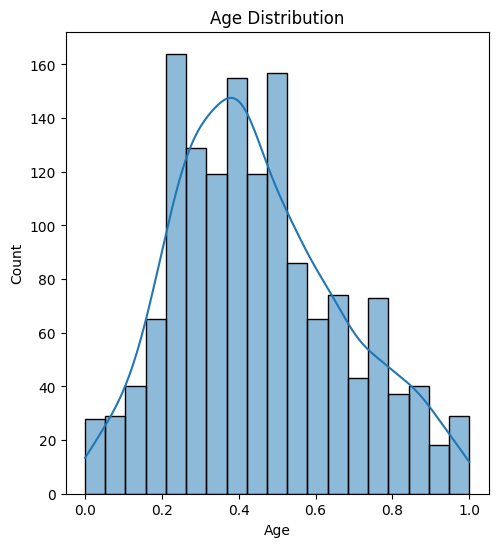

```python
# Univariate Analysis
plt.figure(figsize=(12, 6))
plt.subplot(1, 2, 1)
sns.histplot(data['Age'], kde=True)
plt.title('Age Distribution')
```

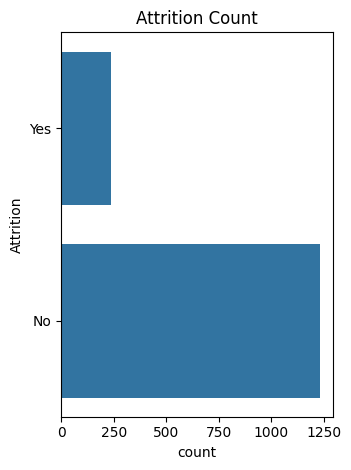

```python
plt.subplot(1, 2, 2)
sns.countplot(df['Attrition'])
plt.title('Attrition Count')
plt.tight_layout()
plt.show()
```

### Bivariate Analysis

To explore the relationship between two numerical variables:

- 'YearsAtCompany'
- 'MonthlyIncome'
- 'Attrition' (target variable)

A scatter plot was created. The 'Attrition' variable was used to color-code the data points, enabling the visualization of the relationship between the predictor variables and the target variable.

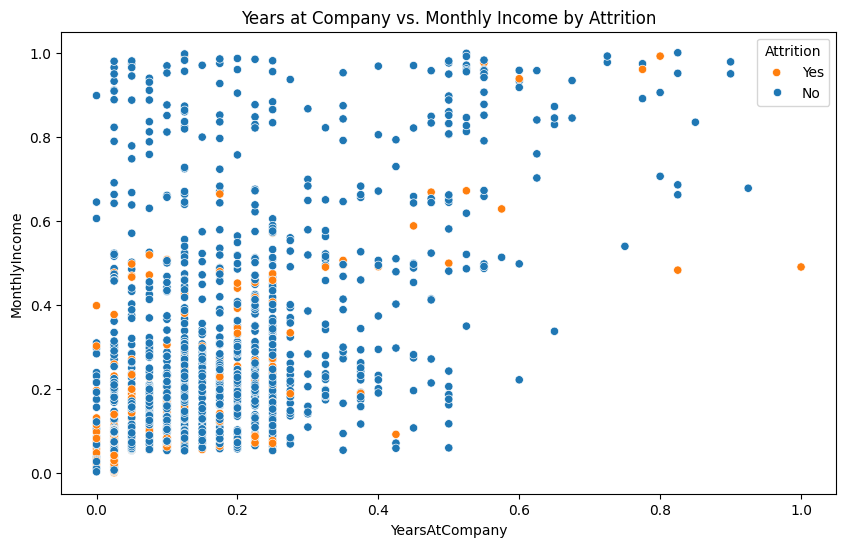

```python
# Encoding in Week 1 converted the text Yes/No into numaricals 1/0
hue_labels = {1: "Yes", 0: "No"}

plt.figure(figsize=(10, 6))
sns.scatterplot(x='YearsAtCompany', y='MonthlyIncome', hue='Attrition', data=data)
plt.title('Years at Company vs. Monthly Income by Attrition')
plt.legend(labels=hue_labels.values(), title="Attrition")
plt.show()
```

### Multivariate Analysis

Multivariate analysis was conducted to visualize the relationships between multiple numerical variables:

- 'Age'
- 'DistanceFromHome'
- 'YearsAtCompany'
- 'MonthlyIncome'
- 'Attrition' (target variable)

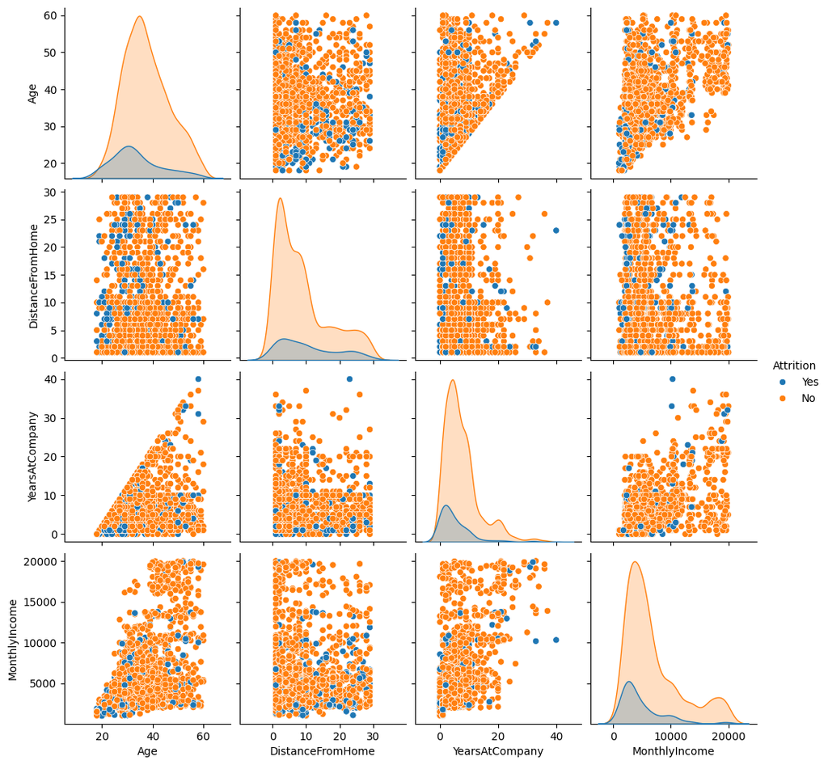

```python
# Multivariate Analysis
plt.figure(figsize=(12, 8))
sns.pairplot(df[['Age', 'DistanceFromHome', 'YearsAtCompany', 'MonthlyIncome', 'Attrition']], hue='Attrition')
plt.show()
```

### Correlation Matrix

To explore the relationships between numerical variables, a correlation matrix was computed and visualized. These analyses and visualizations provided valuable insights into the dataset, including the distribution of variables, potential patterns or relationships between variables, and the presence of any anomalies or data quality issues.

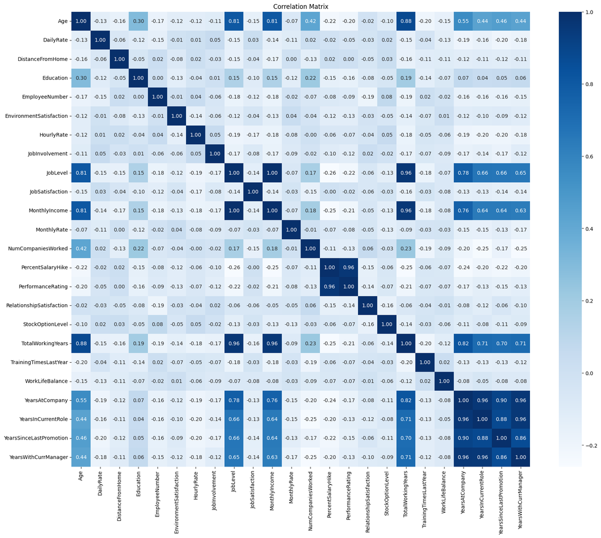

```python
# Correlation Matrix
numeric_data = df.select_dtypes(include='number').drop(columns=['EmployeeCount', 'StandardHours'])
correlation_matrix = numeric_data.corr()


plt.figure(figsize=(20, 16))
sns.heatmap(correlation_matrix.corr(), annot=True, cmap='Blues' ,fmt = ".2f")
plt.title('Correlation Matrix')
plt.show()
```

## Week 3 | Train/test split, model building, parameter tuning

### Splitting data into Train-Test :

```python
# Split the data into train and test set
from sklearn.model_selection import train_test_split

X = data.drop('Attrition', axis=1)
y = data['Attrition']

X_train, X_test, Y_train, Y_test = train_test_split(X, y, test_size=0.2, random_state=42)
```

### LogisticRegression

parameters:{'C': [0.25, 0.5, 0.75, 1],  
'penalty': ['l1', 'l2'],  
'solver': ['liblinear'saga']}

```python
from sklearn.model_selection import KFold
from sklearn.model_selection import GridSearchCV
from sklearn.linear_model import LogisticRegression

kf = KFold(n_splits=10, shuffle=True, random_state=42)

param_grid = {'C': [0.25, 0.5, 0.75, 1],
              'penalty': ['l1', 'l2'],
              'solver': ['liblinear', 'saga'],
              'max_iter': [1000]}


lr = LogisticRegression()

grid_search = GridSearchCV(estimator=lr, param_grid=param_grid, cv=kf, scoring='accuracy')

# Fit the GridSearchCV object to the data
grid_search.fit(X_train,Y_train)

print(grid_search.best_params_)
print(grid_search.best_score_)
```

```
{'C': 0.75, 'max_iter': 1000, 'penalty': 'l2', 'solver': 'liblinear'}
0.8622338113863537
```

These results indicate that the optimal Logistic Regression model, with the specified hyperparameters, achieves an accuracy of approximately 86.22% on the training data. This provides a strong baseline for the model's performance, which can be further evaluated on the held-out test set to assess its generalization capabilities.

```python
# Save the best-trained model to a file
best_model = grid_search.best_estimator_

# Fit the GridSearchCV object to the data
grid_search.fit(X_train,Y_train)
```

[output not shown]

In the given scenario,the GridSearchCV object takes the Logistic Regression model as the estimator and a parameter grid as input. By fitting the GridSearchCV object to the training data (X_train, Y_train), the algorithm systematically evaluates the performance of the Logistic Regression model for each combination of the specified hyperparameters using a cross-validation procedure in this case, 10-fold cross-validation. This ensures that the model's performance is evaluated on multiple subsets of the training data, providing a more robust estimate of the model's generalization capabilities.

```python
# Save the trained model to disk
import pickle
with open('logistic_model_best.pkl', 'wb') as file:
    pickle.dump(best_model, file)
```

```python
# Load the saved model from disk
import pickle
with open('logistic_model_best.pkl', 'rb') as file:
    best_model = pickle.load(file)
```

After training and optimizing the Logistic Regression model using techniques like GridSearchCV, it's important to save the best-performing model for future use. This allows us to quickly load the pre-trained model and apply it to new data, without having to go through the entire model training process again.

Pickle is a standard Python library that can serialize and deserialize Python objects, making it easy to save and load models.This process will be repeated for each model.

### SVM

param_grid = {  
'C': [0.25, 0.5, 0.75, 1],  
'kernel': ['linear', 'poly', 'rbf', 'sigmoid'],  
'gamma': ['scale', 'auto'],  
'degree': [2, 3, 4]

```python
from sklearn.svm import SVC

kf = KFold(n_splits=10, shuffle=True, random_state=42)

param_grid = {
    'C': [0.25, 0.5, 0.75, 1],
    'kernel': ['linear', 'poly', 'rbf', 'sigmoid'],
    'gamma': ['scale', 'auto'],
    'degree': [2, 3, 4]
}

svc = SVC()

# Create a GridSearchCV object with the specified parameter grid and cross-validation method
grid_search = GridSearchCV(estimator=svc, param_grid=param_grid, cv=kf, scoring='accuracy')

# Fit the GridSearchCV object to the data
grid_search.fit(X_train,Y_train)

print(grid_search.best_params_)
print(grid_search.best_score_)
```

```
{'C': 1, 'degree': 2, 'gamma': 'scale', 'kernel': 'linear'}
0.8605026799942053
```

With this optimal configuration, the SVM model achieved a training accuracy score of 86.05%. This indicates that the model is able to correctly classify the training samples with a high degree of accuracy, suggesting that it has learned the underlying patterns in the data effectively.

```python
# Save the best-trained model to a file
best_model = grid_search.best_estimator_

# Fit the GridSearchCV object to the data
grid_search.fit(X_train,Y_train)
```

```
GridSearchCV(cv=KFold(n_splits=10, random_state=42, shuffle=True),
             estimator=SVC(),
             param_grid={'C': [0.25, 0.5, 0.75, 1], 'degree': [2, 3, 4],
                         'gamma': ['scale', 'auto'],
                         'kernel': ['linear', 'poly', 'rbf', 'sigmoid']},
             scoring='accuracy')
```

```python
# Save the trained model to disk
import pickle
with open('svc_model_best.pkl', 'wb') as file:
    pickle.dump(best_model, file)
```

### DecisionTreeClassifier

```
param_grid = {
    'criterion': ['gini', 'entropy'],
    'max_depth': [10, 30, 40, 50],
    'min_samples_split': [10, 15, 20, 50],
    'min_samples_leaf': [5, 10, 20, 30],
    'max_features': ['sqrt', 'log2'],
    'random_state': [42]
}
```

```python
from sklearn.tree import DecisionTreeClassifier

kf = KFold(n_splits=10, shuffle=True, random_state=42)

param_grid = {
    'criterion': ['gini', 'entropy'],
    'max_depth': [10, 30, 40, 50],
    'min_samples_split': [10, 15, 20, 50],
    'min_samples_leaf': [5, 10, 20, 30],
    'max_features': ['sqrt', 'log2'],
    'random_state': [42]
}


dt = DecisionTreeClassifier()

# Create a GridSearchCV object with the updated parameter grid and cross-validation method
grid_search = GridSearchCV(estimator=dt, param_grid=param_grid, cv=kf, scoring='accuracy')

# Fit the GridSearchCV object to the data
grid_search.fit(X_train, Y_train)

print(grid_search.best_params_)
print(grid_search.best_score_)
```

```
{'criterion': 'entropy', 'max_depth': 10, 'max_features': 'sqrt', 'min_samples_leaf': 30, 'min_samples_split': 10, 'random_state': 42}
0.8426626104592205
```

With this optimal configuration, the Decision Tree Classifier model achieved a training accuracy score of 84.27%. This indicates that the model is able to correctly classify the training samples with a high degree of accuracy, suggesting that it has learned the underlying patterns in the data effectively.

The performance of the Decision Tree Classifier model on the training data provides a strong baseline for its capabilities.

```python
# Save the best-trained model to a file
best_model = grid_search.best_estimator_

# Fit the GridSearchCV object to the data
grid_search.fit(X_train,Y_train)
```

```
GridSearchCV(cv=KFold(n_splits=10, random_state=42, shuffle=True),
             estimator=DecisionTreeClassifier(),
             param_grid={'criterion': ['gini', 'entropy'],
                         'max_depth': [10, 30, 40, 50],
                         'max_features': ['sqrt', 'log2'],
                         'min_samples_leaf': [5, 10, 20, 30],
                         'min_samples_split': [10, 15, 20, 50],
                         'random_state': [42]},
             scoring='accuracy')
```

```python
# Save the trained model to disk
import pickle
with open('decisiontree_model_best.pkl', 'wb') as file:
    pickle.dump(best_model, file)
```

### Random Forest

```
param_grid = {
    'criterion': ['gini', 'entropy'],
    'n_estimators': [10, 30, 40, 50, 100],
    'min_samples_split': [10, 15, 20, 50],
    'min_samples_leaf': [5, 10, 20, 30],
    'max_features': ['sqrt', 'log2'],
    'bootstrap': [True, False],
    'random_state': [42]
}
```

```python
from sklearn.model_selection import KFold
from sklearn.model_selection import GridSearchCV
from sklearn.ensemble import RandomForestClassifier

kf = KFold(n_splits=10, shuffle=True, random_state=42)

param_grid = {
    'criterion': ['gini', 'entropy'],
    'n_estimators': [10, 30, 40, 50, 100],
    'min_samples_split': [10, 15, 20, 50],
    'min_samples_leaf': [5, 10, 20, 30],
    'max_features': ['sqrt', 'log2'],
    'bootstrap': [True, False],
    'random_state': [42]
}

rf = RandomForestClassifier()

# Create a GridSearchCV object with the specified parameter grid and cross-validation method
grid_search = GridSearchCV(estimator=rf, param_grid=param_grid, cv=kf, scoring='accuracy')

# Fit the GridSearchCV object to the data
grid_search.fit(X_train[:100],Y_train[:100])

print(grid_search.best_params_)
print(grid_search.best_score_)
```

```
{'bootstrap': False, 'criterion': 'gini', 'max_features': 'sqrt', 'min_samples_leaf': 5, 'min_samples_split': 10, 'n_estimators': 10, 'random_state': 42}
0.8800000000000001
```

```python
# Save the best-trained model to a file
best_model = grid_search.best_estimator_

# Fit the GridSearchCV object to the data
grid_search.fit(X_train,Y_train)
```

```
GridSearchCV(cv=KFold(n_splits=10, random_state=42, shuffle=True),
             estimator=RandomForestClassifier(),
             param_grid={'bootstrap': [True, False],
                         'criterion': ['gini', 'entropy'],
                         'max_features': ['sqrt', 'log2'],
                         'min_samples_leaf': [5, 10, 20, 30],
                         'min_samples_split': [10, 15, 20, 50],
                         'n_estimators': [10, 30, 40, 50, 100],
                         'random_state': [42]},
             scoring='accuracy')
```

```python
# Save the trained model to disk
import pickle
with open('rfc_model_best.pkl', 'wb') as file:
    pickle.dump(best_model, file)
```

### KNN

```
param_grid = {
    'n_neighbors': [3, 5, 7, 10],
    'weights': ['uniform', 'distance'],
    'p': [1, 2],
    'algorithm': ['auto', 'kd_tree'],
    'leaf_size': [20, 30, 40]
}
```

```python
from sklearn.neighbors import KNeighborsClassifier

kf = KFold(n_splits=10, shuffle=True, random_state=42)

param_grid = {
    'n_neighbors': [3, 5, 7, 10],
    'weights': ['uniform', 'distance'],
    'p': [1, 2],
    'algorithm': ['auto', 'kd_tree'],
    'leaf_size': [20, 30, 40]
}

knn = KNeighborsClassifier()

# Create a GridSearchCV object with the specified parameter grid and cross-validation method
grid_search = GridSearchCV(estimator=knn, param_grid=param_grid, cv=kf, scoring='accuracy')

# Fit the GridSearchCV object to the data
grid_search.fit(X_train[:100],Y_train[:100])

print(grid_search.best_params_)
print(grid_search.best_score_)
```

```
{'algorithm': 'auto', 'leaf_size': 20, 'n_neighbors': 3, 'p': 1, 'weights': 'uniform'}
0.8800000000000001
```

With this optimal configuration, the KNN Classifier model achieved a training accuracy score of 88.00%. This indicates that the model is able to correctly classify the training samples with a high degree of accuracy, suggesting that it has learned the underlying patterns in the data effectively. The performance of the KNN Classifier model on the training data provides a strong baseline for its capabilities.

```python
# Save the best-trained model to a file
best_model = grid_search.best_estimator_

# Fit the GridSearchCV object to the data
grid_search.fit(X_train,Y_train)
```

```
GridSearchCV(cv=KFold(n_splits=10, random_state=42, shuffle=True),
             estimator=KNeighborsClassifier(),
             param_grid={'algorithm': ['auto', 'kd_tree'],
                         'leaf_size': [20, 30, 40],
                         'n_neighbors': [3, 5, 7, 10], 'p': [1, 2],
                         'weights': ['uniform', 'distance']},
             scoring='accuracy')
```

```python
# Save the trained model to disk
import pickle
with open('knn_model_best.pkl', 'wb') as file:
    pickle.dump(best_model, file)
```

## Week 4 | Model evaluation and selection

```python
!ls
```

```
AttritionDataset.csv  pickle
```

```python
os.chdir('/content/drive/MyDrive/MRP/Dataset/pickle')
```

```python
import pickle
models = {
    'logistic': None,
    'svc': None,
    'decisiontree': None,
    'rfc': None,
    'knn': None,
}

for model_name in models.keys():
    with open(f'{model_name}_model_best.pkl', 'rb') as f:
        models[model_name] = pickle.load(f)

# Access each model using the corresponding key
lr_model = models['logistic']
svm_model = models['svc']
dt_model = models['decisiontree']
rf_model = models['rfc']
knn_model = models['knn']
```

running cross vald on all the models and finding all the mettrics

```python
import numpy as np
from sklearn.model_selection import cross_val_score
from sklearn.metrics import make_scorer, precision_score, recall_score, f1_score
```

### 3 Fold cross validation

The purpose of this code is to comprehensively evaluate the performance of the different ML models using cross-validation. By using 3, 5, and 10-fold cross-validation, the code provides a more robust and reliable estimate of the models' performance, as it reduces the impact of potentially biased splits of the training and validation data.

The performance metrics calculated (accuracy, recall, precision, and F1-score) give a well-rounded view of the models' capabilities, as they capture different aspects of model performance, such as overall prediction accuracy, class-specific recall, and the balance between precision and recall.

```python
models = [lr_model, svm_model, dt_model, rf_model, knn_model]
scoring = ['accuracy', make_scorer(precision_score, average='weighted'),
           make_scorer(recall_score, average='macro'), make_scorer(f1_score, average='macro')]

cv_scores = []

for i, model_name in enumerate(['Logistic Regression', 'SVM', 'Decision Trees', 'Random Forest', 'KNN']):
    model = models[i]
    cv_scores.append({
        'Methods': model_name,
        'Dataset': '3-fold CV',
        'Accuracy': np.mean(cross_val_score(model, X_train, Y_train, cv=3, scoring='accuracy')),
        'Recall': np.mean(cross_val_score(model, X_train, Y_train, cv=3, scoring=make_scorer(recall_score, average='macro'))),
        'Precision': np.mean(cross_val_score(model, X_train, Y_train, cv=3, scoring=make_scorer(precision_score, average='weighted'))),
        'F1-Score': np.mean(cross_val_score(model, X_train, Y_train, cv=3, scoring=make_scorer(f1_score, average='macro')))
    })

cv_scores_3 = pd.DataFrame(cv_scores)
```

### 5 Fold cross validation

```python
cv_scores = []

for i, model_name in enumerate(['Logistic Regression', 'SVM', 'Decision Trees', 'Random Forest', 'KNN']):
    model = models[i]
    cv_scores.append({
        'Methods': model_name,
        'Dataset': '5-fold CV',
        'Accuracy': np.mean(cross_val_score(model, X_train, Y_train, cv=5, scoring='accuracy')),
        'Recall': np.mean(cross_val_score(model, X_train, Y_train, cv=5, scoring=make_scorer(recall_score, average='macro'))),
        'Precision': np.mean(cross_val_score(model, X_train, Y_train, cv=5, scoring=make_scorer(precision_score, average='weighted'))),
        'F1-Score': np.mean(cross_val_score(model, X_train, Y_train, cv=5, scoring=make_scorer(f1_score, average='macro')))
    })

cv_scores_5 = pd.DataFrame(cv_scores)
```

### 10 Fold cross validation

```python
cv_scores = []

for i, model_name in enumerate(['Logistic Regression', 'SVM', 'Decision Trees', 'Random Forest', 'KNN']):
    model = models[i]
    cv_scores.append({
        'Methods': model_name,
        'Dataset': '10-fold CV',
        'Accuracy': np.mean(cross_val_score(model, X_train, Y_train, cv=10, scoring='accuracy')),
        'Recall': np.mean(cross_val_score(model, X_train, Y_train, cv=10, scoring=make_scorer(recall_score, average='macro'))),
        'Precision': np.mean(cross_val_score(model, X_train, Y_train, cv=10, scoring=make_scorer(precision_score, average='weighted'))),
        'F1-Score': np.mean(cross_val_score(model, X_train, Y_train, cv=10, scoring=make_scorer(f1_score, average='macro')))
    })

cv_scores_10 = pd.DataFrame(cv_scores)
```

### Train set metrics

This process evaluates the performance of various ML models on a training dataset by calculating key metrics (accuracy, recall, precision, and F1-score) for each model. The results are then compiled to assess the collective performance. For each model, the code fetches the relevant model from an existing dictionary, trains it on the data, and predicts the training labels. The metrics are computed by comparing the actual and predicted labels, with the outcomes recorded in a dictionary. The final DataFrame offers a detailed overview of each model's performance and the aggregate performance of all models.

```python
from sklearn.metrics import accuracy_score, recall_score, precision_score, f1_score

train_scores = []

for i, model_name in enumerate(['Logistic Regression', 'SVM', 'Decision Trees', 'Random Forest', 'KNN']):
    model = models[i]
    model.fit(X_train, Y_train)
    y_pred = model.predict(X_train)

    train_scores.append({
        'Methods': model_name,
        'Dataset': 'Train',
        'Accuracy': accuracy_score(Y_train, y_pred),
        'Recall': recall_score(Y_train, y_pred),
        'Precision': precision_score(Y_train, y_pred),
        'F1-Score': f1_score(Y_train, y_pred)
    })

train_scores_df = pd.DataFrame(train_scores)

# Calculate the total scores
total_scores = train_scores_df.drop(['Dataset', 'Methods'], axis=1).mean().to_frame().T
total_scores['Dataset'] = 'Total'
total_scores['Methods'] = 'All Methods'
total_scores = total_scores[['Methods', 'Dataset', 'Accuracy', 'Recall', 'Precision', 'F1-Score']]

# Concatenate train_scores_df and total_scores
# pd.concat([train_scores_df, total_scores], ignore_index=True)
train_scores_df = pd.concat([train_scores_df, total_scores], ignore_index=True)
```

### Test set metrics

This snippet of code performance evaluation for each ML models on a test dataset. Same as above code but on train dataset.

```python
from sklearn.metrics import precision_score, recall_score, f1_score
test_scores = []

for i, model_name in enumerate(['Logistic Regression', 'SVM', 'Decision Trees', 'Random Forest', 'KNN']):
    model = models[i]
    model.fit(X_test, Y_test)
    y_pred = model.predict(X_test)

    test_scores.append({
        'Methods': model_name,
        'Dataset': 'Test',
        'Accuracy': accuracy_score(Y_test, y_pred),
        'Recall': recall_score(Y_test, y_pred),
        'Precision': precision_score(Y_test, y_pred),
        'F1-Score': f1_score(Y_test, y_pred)
    })

test_scores = pd.DataFrame(test_scores)
```

## Evaluation Summery

This code is designed to clearly and systematically present the performance metrics of various machine learning models. It displays results using different cross-validation techniques (3-fold, 5-fold, and 10-fold) across both training and test datasets, offering a thorough assessment of the models' effectiveness.

```python
print("\n *************** 3 fold CV metric values ***************")
display(cv_scores_3)
print("\n *************** 5 fold CV metric values ***************")
display(cv_scores_5)
print("\n *************** 10 fold CV metric values **************")
display(cv_scores_10)
print("\n *************** Train Dataset metric values ***********")
display(train_scores_df)
print("\n *************** Test Dataset metric values ************")
display(test_scores)
```

```
 *************** 3 fold CV metric values ***************
```

|  | Methods | Dataset | Accuracy | Recall | Precision | F1-Score |
| --- | --- | --- | --- | --- | --- | --- |
| 0 | Logistic Regression | 3-fold CV | 0.851190 | 0.622529 | 0.830350 | 0.649398 |
| 1 | SVM | 3-fold CV | 0.858844 | 0.627130 | 0.845537 | 0.658719 |
| 2 | Decision Trees | 3-fold CV | 0.851190 | 0.596347 | 0.832646 | 0.615914 |
| 3 | Random Forest | 3-fold CV | 0.850340 | 0.597850 | 0.836940 | 0.622132 |
| 4 | KNN | 3-fold CV | 0.836735 | 0.589670 | 0.806331 | 0.606546 |

```
 *************** 5 fold CV metric values ***************
```

|  | Methods | Dataset | Accuracy | Recall | Precision | F1-Score |
| --- | --- | --- | --- | --- | --- | --- |
| 0 | Logistic Regression | 5-fold CV | 0.846949 | 0.617996 | 0.821217 | 0.640900 |
| 1 | SVM | 5-fold CV | 0.857155 | 0.630232 | 0.837991 | 0.659842 |
| 2 | Decision Trees | 5-fold CV | 0.853722 | 0.605539 | 0.830172 | 0.624955 |
| 3 | Random Forest | 5-fold CV | 0.852034 | 0.604767 | 0.831176 | 0.626372 |
| 4 | KNN | 5-fold CV | 0.828226 | 0.580239 | 0.793764 | 0.590997 |

```
 *************** 10 fold CV metric values **************
```

|  | Methods | Dataset | Accuracy | Recall | Precision | F1-Score |
| --- | --- | --- | --- | --- | --- | --- |
| 0 | Logistic Regression | 10-fold CV | 0.853752 | 0.624241 | 0.830194 | 0.650751 |
| 1 | SVM | 10-fold CV | 0.868195 | 0.644885 | 0.859973 | 0.681142 |
| 2 | Decision Trees | 10-fold CV | 0.831588 | 0.570127 | 0.794228 | 0.580011 |
| 3 | Random Forest | 10-fold CV | 0.853759 | 0.605954 | 0.833860 | 0.627740 |
| 4 | KNN | 10-fold CV | 0.823975 | 0.576653 | 0.785972 | 0.584730 |

```
 *************** Train Dataset metric values ***********
```

|  | Methods | Dataset | Accuracy | Recall | Precision | F1-Score |
| --- | --- | --- | --- | --- | --- | --- |
| 0 | Logistic Regression | Train | 0.870748 | 0.333333 | 0.767442 | 0.464789 |
| 1 | SVM | Train | 0.871599 | 0.318182 | 0.797468 | 0.454874 |
| 2 | Decision Trees | Train | 0.846939 | 0.257576 | 0.607143 | 0.361702 |
| 3 | Random Forest | Train | 0.945578 | 0.681818 | 0.992647 | 0.808383 |
| 4 | KNN | Train | 0.895408 | 0.489899 | 0.815126 | 0.611987 |
| 5 | All Methods | Total | 0.886054 | 0.416162 | 0.795965 | 0.540347 |

```
 *************** Test Dataset metric values ************
```

|  | Methods | Dataset | Accuracy | Recall | Precision | F1-Score |
| --- | --- | --- | --- | --- | --- | --- |
| 0 | Logistic Regression | Test | 0.877551 | 0.076923 | 1.000000 | 0.142857 |
| 1 | SVM | Test | 0.880952 | 0.102564 | 1.000000 | 0.186047 |
| 2 | Decision Trees | Test | 0.867347 | 0.000000 | 0.000000 | 0.000000 |
| 3 | Random Forest | Test | 0.942177 | 0.564103 | 1.000000 | 0.721311 |
| 4 | KNN | Test | 0.891156 | 0.282051 | 0.733333 | 0.407407 |

### Random Forest is the best performing model

```python
import pandas as pd

print("\n *************** Random Forest Model Performance ***************")

rf_3_cv = cv_scores_3.loc[cv_scores_3['Methods'] == 'Random Forest', ['Accuracy', 'Recall', 'Precision', 'F1-Score']]
rf_3_cv.index = ['3-fold CV']

rf_5_cv = cv_scores_5.loc[cv_scores_5['Methods'] == 'Random Forest', ['Accuracy', 'Recall', 'Precision', 'F1-Score']]
rf_5_cv.index = ['5-fold CV']

rf_10_cv = cv_scores_10.loc[cv_scores_10['Methods'] == 'Random Forest', ['Accuracy', 'Recall', 'Precision', 'F1-Score']]
rf_10_cv.index = ['10-fold CV']

rf_train = train_scores_df.loc[train_scores_df['Methods'] == 'Random Forest', ['Accuracy', 'Recall', 'Precision', 'F1-Score']]
rf_train.index = ['Training']

rf_test = test_scores.loc[test_scores['Methods'] == 'Random Forest', ['Accuracy', 'Recall', 'Precision', 'F1-Score']]
rf_test.index = ['Test']


pd.concat([rf_3_cv, rf_5_cv, rf_10_cv, rf_train, rf_test])
```

```
 *************** Random Forest Model Performance ***************
```

|  | Accuracy | Recall | Precision | F1-Score |
| --- | --- | --- | --- | --- |
| 3-fold CV | 0.850340 | 0.597850 | 0.836940 | 0.622132 |
| 5-fold CV | 0.852034 | 0.604767 | 0.831176 | 0.626372 |
| 10-fold CV | 0.853759 | 0.605954 | 0.833860 | 0.627740 |
| Training | 0.945578 | 0.681818 | 0.992647 | 0.808383 |
| Test | 0.942177 | 0.564103 | 1.000000 | 0.721311 |

Based on the performance metrics output, the best performing model is the **Random Forest** model.

## Week 5

### ROC analysis

ROC curves are used to evaluate the performance of binary classification models. The ROC curve plots the true positive rate (TPR) on the y-axis against the false positive rate (FPR) on the x-axis.

The ROC curve shows the performance of five different classification models. The area under the curve (AUC) is a metric that summarizes the performance of a classification model. A larger AUC indicates a better overall performance.

- The closer the ROC curve is to the upper left corner, the better the performance of the model.
- A ROC curve that is closer to a diagonal line indicates a model that is no better than random guessing.
- The point on the ROC curve where the TPR is equal to the FPR is known as the crossover point. The crossover point can be used to select a classification threshold that balances the TPR and the FPR.

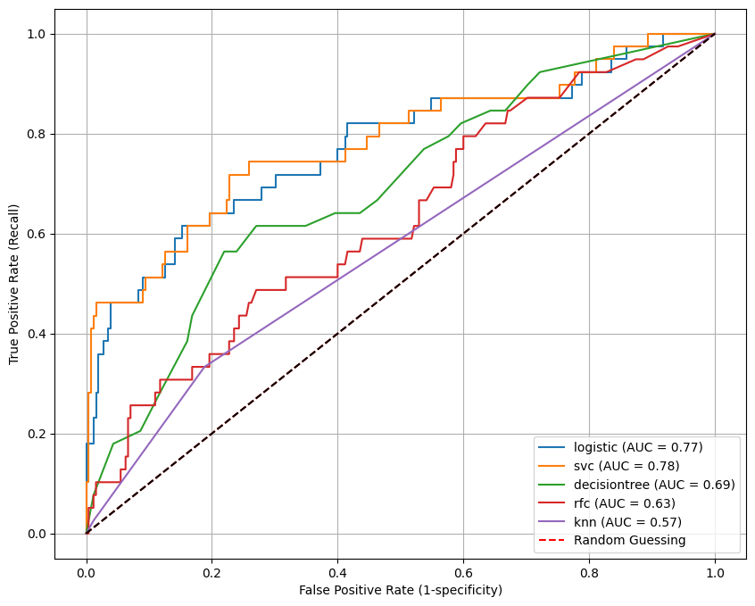

```python
import matplotlib.pyplot as plt
from sklearn.metrics import roc_curve, auc

# Define a list to store the decision scores for each model
decision_scores = []

# Make predictions and calculate decision scores for each model
for model in [lr_model, svm_model, dt_model, rf_model, knn_model]:
    if hasattr(model, "decision_function"):
        decision_scores.append(model.decision_function(x_test))
    elif hasattr(model, "predict_proba"):
        decision_scores.append(model.predict_proba(x_test)[:, 1])

# Plot ROC curves for each model
plt.figure(figsize=(10, 8))
for idx, scores in enumerate(decision_scores):
    fpr, tpr, _ = roc_curve(y_test, scores)
    roc_auc = auc(fpr, tpr)
    model_name = ['logistic', 'svc', 'decisiontree', 'rfc', 'knn'][idx]
    plt.plot(fpr, tpr, label=f'{model_name} (AUC = {roc_auc:.2f})')

# Plot ROC curve for random guessing
plt.plot([0, 1], [0, 1], linestyle='--', color='r', label='Random Guessing')

plt.plot([0, 1], [0, 1], 'k--')
plt.xlabel('False Positive Rate (1-specificity)')
plt.ylabel('True Positive Rate (Recall)')
plt.legend(loc='lower right')
plt.grid(True)
plt.show()
```

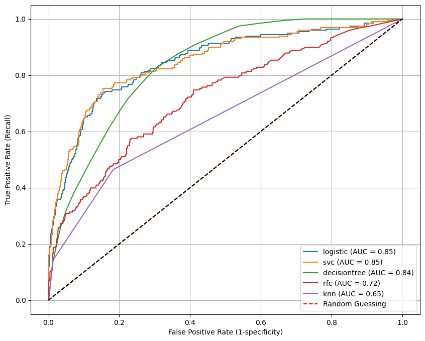

```python
import matplotlib.pyplot as plt
from sklearn.metrics import roc_curve, auc

# Define a list to store the decision scores for each model
decision_scores = []

# Make predictions and calculate decision scores for each model
for model in [lr_model, svm_model, dt_model, rf_model, knn_model]:
    if hasattr(model, "decision_function"):
        decision_scores.append(model.decision_function(x_train))
    elif hasattr(model, "predict_proba"):
        decision_scores.append(model.predict_proba(x_train)[:, 1])

# Plot ROC curves for each model
plt.figure(figsize=(10, 8))
for idx, scores in enumerate(decision_scores):
    fpr, tpr, _ = roc_curve(y_train, scores)
    roc_auc = auc(fpr, tpr)
    model_name = ['logistic', 'svc', 'decisiontree', 'rfc', 'knn'][idx]
    plt.plot(fpr, tpr, label=f'{model_name} (AUC = {roc_auc:.2f})')

# Plot ROC curve for random guessing
plt.plot([0, 1], [0, 1], linestyle='--', color='r', label='Random Guessing')

plt.plot([0, 1], [0, 1], 'k--')
plt.xlabel('False Positive Rate (1-specificity)')
plt.ylabel('True Positive Rate (Recall)')
plt.legend(loc='lower right')
plt.grid(True)
plt.show()
```

On **Testing Set** : svc ,then logistic regression, decision tree, rfc, and knn

On **Training Set** : The logistic regression model is the best followed by svc, decision tree, random forest, and knn.

We observed that Random Forest outperformed Support Vector Machine (SVM) in terms of Accuracy, Recall, Precision, and F1-Score. However, SVM achieved a higher ROC AUC score, indicating better overall performance across different thresholds. These metrics are sensitive to the chosen threshold and can be influenced by class imbalance in the dataset.

The SVM model may have a better overall performance across different classification thresholds, as indicated by the higher AUC-ROC. However, at the specific threshold used to compute accuracy, recall, and F1 score, the Random Forest model may perform better.

These metrics are used for different purposes:

- ROC curve and AUC-ROC are useful for evaluating overall model performance and comparing multiple models, especially when the class distribution is imbalanced.
- Accuracy is a good metric when the classes are balanced and the cost of misclassification is equal for both classes.
- Recall is important when you want to minimize false negatives (e.g., in a medical diagnosis scenario where missing a positive case is costly).
- F1 score is a balanced metric that considers both precision and recall, useful when you want to find a good trade-off between the two.

The choice of the appropriate metric depends on the specific problem and the relative importance of minimizing false positives or false negatives.

### Important features ranking

#### Tree based models

Feature importance is calculated as the decrease in node impurity weighted by the probability of reaching that node. The node probability can be calculated by the number of samples that reach the node, divided by the total number of samples. The higher the value the more important the feature.

```python
import pandas as pd
from sklearn.ensemble import RandomForestClassifier

importances = rf_model.feature_importances_
feature_importances = pd.Series(importances, index=x_train.columns)

# descending order
feature_importances.sort_values(ascending=False, inplace=True)

feature_importances
```

```
OverTime                    0.126895
MonthlyIncome               0.094574
TotalWorkingYears           0.089830
Age                         0.053471
EmployeeNumber              0.047464
JobLevel                    0.041731
HourlyRate                  0.041441
StockOptionLevel            0.040707
YearsAtCompany              0.040592
NumCompaniesWorked          0.036730
DailyRate                   0.036403
JobRole                     0.035938
DistanceFromHome            0.035792
PercentSalaryHike           0.025980
MonthlyRate                 0.025802
MaritalStatus               0.025735
YearsInCurrentRole          0.021238
YearsSinceLastPromotion     0.021042
JobInvolvement              0.017723
JobSatisfaction             0.017439
EnvironmentSatisfaction     0.016989
RelationshipSatisfaction    0.016671
Education                   0.016507
WorkLifeBalance             0.015499
TrainingTimesLastYear       0.014261
YearsWithCurrManager        0.014139
EducationField              0.010197
BusinessTravel              0.008956
Department                  0.005828
Gender                      0.004330
PerformanceRating           0.000098
StandardHours               0.000000
EmployeeCount               0.000000
Over18                      0.000000
dtype: float64
```

#### SVM model

'**feature_importances**' is for tree based desicion models and can not be applicable for SVM model which relie on coefficients or Permutation Importance

'**permutation_importance**' is permuting the values of each feature one at a time and measuring how much the permutation affects the model's performance. Features that, when permuted, cause the most significant drop in performance are considered more important.

```python
from sklearn.inspection import permutation_importance

result = permutation_importance(svm_model, x_test, y_test, n_repeats=10, random_state=42)
importances = result.importances_mean
feature_names = x_test.columns
feature_importances = pd.Series(importances, index=feature_names)

# descending order
feature_importances.sort_values(ascending=False, inplace=True)

feature_importances
```

```
OverTime                    0.030952
JobInvolvement              0.015986
YearsInCurrentRole          0.011565
Department                  0.011565
WorkLifeBalance             0.010884
EnvironmentSatisfaction     0.010884
MaritalStatus               0.008503
JobSatisfaction             0.008503
YearsWithCurrManager        0.006803
JobLevel                    0.006803
NumCompaniesWorked          0.006122
TotalWorkingYears           0.005782
Age                         0.004762
YearsSinceLastPromotion     0.003401
Gender                      0.003061
DistanceFromHome            0.002381
StockOptionLevel            0.002381
MonthlyIncome               0.001701
EducationField              0.001701
DailyRate                   0.001361
EmployeeNumber              0.000680
StandardHours               0.000000
PerformanceRating           0.000000
PercentSalaryHike           0.000000
Over18                      0.000000
EmployeeCount               0.000000
MonthlyRate                -0.000340
HourlyRate                 -0.000340
Education                  -0.000680
BusinessTravel             -0.002381
TrainingTimesLastYear      -0.002721
RelationshipSatisfaction   -0.005442
JobRole                    -0.008503
YearsAtCompany             -0.008844
dtype: float64
```

```python
# Creating a Dataframe of all the ML models feature importance values

import seaborn as sns

feature_importances_dict = {}

for model_name, model in models.items():

    model.fit(x_train, y_train)
    result = permutation_importance(model, x_test, y_test, n_repeats=10, random_state=46)
    importances = result.importances_mean
    feature_importances = pd.Series(importances, index=x_test.columns)
    feature_importances_dict[model_name] = feature_importances * 100

feature_importances_df = pd.DataFrame(feature_importances_dict)
```

```python
feature_importances_dt = feature_importances_df.T
feature_importances_dt
```

|  | Age | BusinessTravel | DailyRate | Department | DistanceFromHome | Education | EducationField | EmployeeCount | EmployeeNumber | EnvironmentSatisfaction | ... | RelationshipSatisfaction | StandardHours | StockOptionLevel | TotalWorkingYears | TrainingTimesLastYear | WorkLifeBalance | YearsAtCompany | YearsInCurrentRole | YearsSinceLastPromotion | YearsWithCurrManager |
| --- | --- | --- | --- | --- | --- | --- | --- | --- | --- | --- | --- | --- | --- | --- | --- | --- | --- | --- | --- | --- | --- |
| logistic | 3.401361e-01 | -0.204082 | -0.034014 | 0.272109 | -0.238095 | 0.102041 | -0.340136 | 0.0 | 0.000000 | 0.748299 | ... | -0.136054 | 0.0 | 0.034014 | 0.204082 | 0.000000 | 0.442177 | -0.408163 | 0.408163 | 0.272109 | 0.306122 |
| svc | 7.482993e-01 | -0.442177 | 0.170068 | 1.598639 | 0.442177 | 0.000000 | 0.170068 | 0.0 | 0.204082 | 0.884354 | ... | -0.340136 | 0.0 | 0.340136 | 0.816327 | -0.204082 | 0.510204 | -0.782313 | 1.292517 | 0.884354 | 1.020408 |
| decisiontree | 0.000000e+00 | 0.000000 | 0.374150 | 0.000000 | 0.000000 | 0.000000 | 0.000000 | 0.0 | 0.000000 | 0.000000 | ... | 0.000000 | 0.0 | 1.734694 | 0.238095 | -0.340136 | 0.000000 | 0.000000 | 0.000000 | 0.000000 | 0.000000 |
| rfc | -2.040816e-01 | -0.408163 | -0.510204 | -0.306122 | 0.238095 | -0.238095 | -0.136054 | 0.0 | -0.578231 | 0.000000 | ... | -0.136054 | 0.0 | 0.136054 | 0.340136 | -0.034014 | -0.204082 | 0.170068 | -0.714286 | -0.170068 | 0.000000 |
| knn | 1.110223e-15 | -0.136054 | -1.530612 | 0.034014 | -1.156463 | -1.428571 | -1.428571 | 0.0 | -1.054422 | -0.714286 | ... | -0.782313 | 0.0 | -0.986395 | -0.102041 | -1.156463 | -1.802721 | -0.476190 | -0.544218 | -1.020408 | -1.224490 |

5 rows × 34 columns

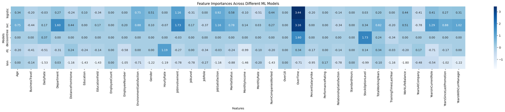

```python
plt.figure(figsize=(36, 4))
sns.heatmap(feature_importances_dt, annot=True, cmap="Blues", fmt=".2f")
plt.title('Feature Importances Across Different ML Models')
plt.xlabel('Features')
plt.ylabel('Models')
plt.show()
```

# Summary

While ROC curves and AUC are commonly used for binary classification tasks, they can provide insights into the trade-offs between true positive rate and false positive rate, which may be relevant depending on the organization's priorities and costs associated with false predictions.

But in the case of predicting employee attrition, **High recall** ensures that the model identifies as many employees at risk of leaving as possible, while **high precision** ensures that the identified cases are accurate, minimizing unnecessary interventions or false alarms.

Therefore, metric F1-score, which consider both precision and recall, can be particularly useful for evaluating model performance in this context

Same as of week 4 conclustion Random Forest model still remains the best ML model for this case.